# Parametric and non-parametric tests for one-sample, paired, and two-sample tests

## Review

### Monday, Feb. 24

- Random samples
- Standard normal distribution
  - What is a $z$-score?
  - What are the quantiles?
  - How do you capture height vs. area?
- Sampling distribution of the sample mean
- Standard error
- Confidence intervals
- What is a $z$-score?
- $t$-statistics vs. $z$-statistics : when is each appropriate?
- P values : one- vs. two-sided
- What does qt(0.975) represent?

### Wednesday, Feb. 26

- Parametric vs. non-parametric tests
- Assumptions of parametric tests
- Checking for normality
  - Visualization: histograms, QQ-plots
  - Shapiro-Wilk test
- Transformations - when to use which one?
  - Log, arcsin, sqrt
- Non-parametric tests
  - Sign test (Alt: Wilcoxon signed-rank test)
    - What are they for? Assumptions?
  - Mann-Whitney U test (Equivalent: Wilcoxon rank-sum test)
    - What are they for? Assumptions?
- Power of non-parametric tests
- Options to consider when choosing a test

## One-sample, paired-sample, and two-sample $t$-tests

This worksheet illustrates basic concepts and practical application of significance tests for different experimental scenarios.

To illustrate the various types of $t$-test, we will use a simple case study where a drug was administered to 10 random patients (or test subjects) and its effect was compared to that of a placebo pill. Three different experimental designs are illustrated:

- Treatment sample vs. control population (one-sample test)
- Two random samples: treatment vs. control (two-sample test)
- One sample measured before and after treatment (paired test)

In all three scenarios, measurements were collected to answer the question:

##### Is there a significant difference between the control subjects and the those who were given the drug?

### Sample data

To generate sample data for this exercise, I drew two random samples, each from a normal population:

```r
# sample data
Placebo = c(54,51,58,44,55,52,42,47,58,46)
Drug = c(54,73,53,70,73,68,52,65,65,60)
```

### Population data

In order to perform a one-sample $t$-test, we technically need to have some data from a control population for comparison, so that we can test our samples against the true population mean. Here, however, we do not have the population data, so what do we do? We can actually reverse engineer a control sample population, using our best estimates of the population parameters using the control sample we do have!

Recall from Chapter 11 that our best estimate for the true population mean $\mu$ is the sample mean $\bar{Y}$. Our best estimate for the true population variance (Section 11.5) is:

$$\sigma^2 = \frac{(n-1)s^2}{\chi^2}$$

That looks pretty simple, but what do we use for Chi-squared? If we were computing a 95% CI for the population SD, we would use $\chi_{\alpha=0.025}$ and $\chi_{\alpha=0.975}$. Instead, here we want a representative value from the sampling distribution of $\chi^2$, so we will use the 50th quantile (the midway point in the density distribution).

Using this information, we can sample from a normal distribution with our estimated parameters and pretend that this is our control population data. It will probably be closer overall to the Placebo sample than the original population, since we have to use the sample statistics to estimate the population parameters, but that’s ok for now.

```r
## estimate the population parameters

# mean
pop_mean_est = mean(Placebo)

# s.d. -- use the sample variance and the Chi-square distribution
# sigma^2 = df * s^2 / chisq_est(0.5,9)
# a) compute chi-squared estimate
chisq_est = qchisq(0.5, length(Placebo)-1)

# b) compute pop sd estimate
pop_sd_est = sqrt( (length(Placebo)-1)*sd(Placebo) / chisq_est )

# check the estimated parameters
paste("Chi-square = ",round(chisq_est,4),
      " ; Pop. SD est. = ",round(pop_sd_est,4))
```

```
## [1] "Chi-square =  8.3428  ; Pop. SD est. =  2.4833"
```

```r
paste("Population mean estimate = ",round(pop_mean_est,3))
```

```
## [1] "Population mean estimate =  50.7"
```

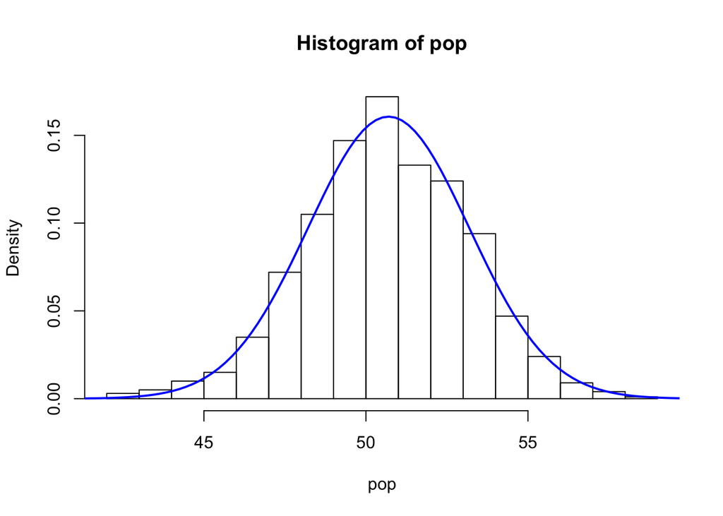

```r
## simulate a population using the estimated population mean and sd
pop = rnorm(1000,mean=pop_mean_est,sd=pop_sd_est)

## visualize the results
hist(pop, breaks=20, freq=FALSE)
xfit = seq(40,60,length=100)
yfit = dnorm(xfit,mean=pop_mean_est,sd=pop_sd_est)
lines(xfit,yfit,col="blue",lwd = 2)
```

```r
## check the parameters from the simulated population
paste("Pop. mean (simulated) = ",round(mean(pop),3),
      " ; Pop. SD (simulated) = ",round(sd(pop),4))
```

```
## [1] "Pop. mean (simulated) =  50.668  ; Pop. SD (simulated) =  2.5031"
```

Compare the estimated vs. simulated population parameters. They are close, but not identical.

### Confidence Intervals for the Population Mean

The standard error is very helpful because it gives us an idea of how close our data are to the actual mean. We can use the SE to help define **Confidence Intervals (CI)** for the the actual population means from which the samples were drawn.

Here, we assume that we have random samples and that the measurements are normally distributed in the population. The estimated distribution of the sample means will then follow a $t$-distribution, which is similar to a standard normal distribution but with heavier tails. As the sample size increases, the tails of the $t$-distribution become smaller and it resembles closely the $Z$-distribution.

Let’s calculate the 95% CI for the mean of each population that the samples are drawn from.

- Estimate the mean and SE for the Placebo and Drug samples.
- Use the `qt()` *quantile function* to identify the critical $t$-score for the the 95% CI with the appropriate $df$.
- Use the estimated means, SEs, and $t_{crit}$ to get the 95% CI’s for the two samples.

```r
## t_critical: # 2.26 = t-score for 97.5% area
# Placebo and Drug are the same length so this works for both
t_0.975 = qt(p = .975, df = length(Placebo)-1)
paste0("t_crit = ",round(t_0.975,4))  # 2.26 = z-score for 97.5% area
```

```
## [1] "t_crit = 2.2622"
```

```r
## placebo
Pmean = mean(Placebo)
Pse=sd(Placebo)/sqrt(length(Placebo))

# 95% CI
c(Pmean - Pse * t_0.975, Pmean + Pse * t_0.975)
```

```
## [1] 46.6107 54.7893
```

```r
## drug
Dmean = mean(Drug)
Dse=sd(Drug)/sqrt(length(Drug))

# 95% CI
c(Dmean - Dse * t_0.975, Dmean + Dse * t_0.975)
```

```
## [1] 57.49772 69.10228
```

We can check our answers by extracting the CI estimates from the `t.test(...)` function. You can inspect the `t.test` object using `str()`; it’s a list containing a bunch of information about the results of the $t$-test. The precise expression to get the CI is `t.test()$confint[1:2]`.

Do this for both the Drug and the Placebo samples. Are these the same as what you calculated above?

```r
t.test(Placebo, mu=mean(pop))$conf.int[1:2]
```

```
## [1] 46.6107 54.7893
```

```r
t.test(Drug, mu=mean(pop))$conf.int[1:2]
```

```
## [1] 57.49772 69.10228
```

Using the rules of thumb given in your textbook, can you conclude by eye that the samples come from different populations? Why or why not?

### One-sample $t$-test

Run a $t$-test for each sample against:

- the mean of the simulated control population, and
- the population mean estimate from just the Placebo sample.

```r
# Placebo sample
t.test(Placebo, mu=mean(pop))
```

```
##
##  One Sample t-test
##
## data:  Placebo
## t = 0.017429, df = 9, p-value = 0.9865
## alternative hypothesis: true mean is not equal to 50.66849
## 95 percent confidence interval:
##  46.6107 54.7893
## sample estimates:
## mean of x
##      50.7
```

```r
t.test(Placebo, mu=mean(Placebo))
```

```
##
##  One Sample t-test
##
## data:  Placebo
## t = 0, df = 9, p-value = 1
## alternative hypothesis: true mean is not equal to 50.7
## 95 percent confidence interval:
##  46.6107 54.7893
## sample estimates:
## mean of x
##      50.7
```

```r
# Drug sample
t.test(Drug, mu=mean(pop))
```

```
##
##  One Sample t-test
##
## data:  Drug
## t = 4.9247, df = 9, p-value = 0.0008193
## alternative hypothesis: true mean is not equal to 50.66849
## 95 percent confidence interval:
##  57.49772 69.10228
## sample estimates:
## mean of x
##      63.3
```

```r
t.test(Drug, mu=mean(Placebo))
```

```
##
##  One Sample t-test
##
## data:  Drug
## t = 4.9124, df = 9, p-value = 0.0008333
## alternative hypothesis: true mean is not equal to 50.7
## 95 percent confidence interval:
##  57.49772 69.10228
## sample estimates:
## mean of x
##      63.3
```

How similar are the results between the tests using the “true” (simulated) population mean and the ones using the sample mean?

Does it make sense to do a `t.test` of the Placebo sample against its own mean?

### Difference between sample means

We already know that the distribution of the sample mean is normally distributed, and that the sum or difference of two normally distributed variables is also normally distributed.

Therefore, the difference in sample means must also be normally distributed, so we can use $t$-statistics to test whether the means are the same, and we can estimate (with 95% confidence) the true difference in the means of the two populations.

#### 95% CI for the difference in sample means

To calculate the 95% CI for $\bar{\mu_D}-\bar{\mu_P}$ using the $t$-distribution, we will need several things:

- the observed mean difference
- the SE of the difference
- the degrees of freedom
- the critical $t$-value

In this example, the standard error is the same whether we use the **pooled variance** formula (for equal variances) or the simpler formula from **Welch’s approximate** $t$-test (for unequal variances), which uses individual sample variances:

$$SE_{\bar{Y}_{1}-\bar{Y}_{2}}={\sqrt{\frac{s_{1}^2}{n_1}+{\frac{s_{2}^2}{n_2}}}}$$

For independent samples, the degrees of freedom are: $df = n_1 + n_2 - 2$.

```r
# mean difference
mean_diff = mean(Drug) - mean(Placebo)  # 12.6
mean_diff
```

```
## [1] 12.6
```

```r
# SE of the difference
se_diff = sqrt ( var(Placebo)/length(Placebo) +
                   var(Drug) /length(Drug) )
se_diff
```

```
## [1] 3.13794
```

```r
# critical t-value
t_crit = abs(qt(p=0.025, df=18))  # same as qt(p=0.975, df=18)
t_crit
```

```
## [1] 2.100922
```

```r
# 95% CI
c(mean_diff - t_crit * se_diff, mean_diff +  t_crit * se_diff)
```

```
## [1]  6.007433 19.192567
```

Notice that the confidence interval does not span 0, which means it is extremely unlikely that the true difference between the Drug and Placebo populations is 0.

Let’s check this using a $t$-test.

#### Two-sample $t$-test

The **null hypothesis** is that the difference between the two populations is 0. We know this because if we were to plot a distribution of random variables with the same mean, we would expect to get a mean difference of 0.

$$H_o : \mu_{Drug} = \mu_{Placebo}$$
$$H_A : \mu_{Drug} \ne \mu_{Placebo}$$

Since we expect that we have random samples drawn from a normal distribution, it is valud to use $t$-statistics to test our null hypothesis.

Recall that the $t$-score for the difference in the means is computed in the same way as the $z$-score for a normal distribution: it is simply the difference *standardized* by the standard error. We already computed the mean and SE above, so this will be very easy!

First, calculate by hand the test statistic (the $t$-score for the observed difference) and use it to find the probability that our null hypothesis is true (the $p$-value for our test statistic).

Next, perform a two-sample test using the `t.test()`. Try both the standard version and Welch’s approximate $t$-test.

```r
# compute the test statistic for the mean difference
t_score = mean_diff / se_diff
t_score
```

```
## [1] 4.015373
```

```r
# compute a two-sided p-value
2*pt(q = t_score,
     df = (length(Placebo)+length(Drug)-2),
     lower.tail = F)
```

```
## [1] 0.0008115625
```

```r
# perform two versions of a 2-sample test using R
t.test(Drug, Placebo, var.equal = T)
```

```
##
##  Two Sample t-test
##
## data:  Drug and Placebo
## t = 4.0154, df = 18, p-value = 0.0008116
## alternative hypothesis: true difference in means is not equal to 0
## 95 percent confidence interval:
##   6.007433 19.192567
## sample estimates:
## mean of x mean of y
##      63.3      50.7
```

```r
t.test(Drug, Placebo, var.equal = F)
```

```
##
##  Welch Two Sample t-test
##
## data:  Drug and Placebo
## t = 4.0154, df = 16.171, p-value = 0.0009803
## alternative hypothesis: true difference in means is not equal to 0
## 95 percent confidence interval:
##   5.95359 19.24641
## sample estimates:
## mean of x mean of y
##      63.3      50.7
```

How do the results of the manual calculation and the two $t$-tests compare?

What is similar and what is different about these results in comparison with the one-sample tests above?

#### Paired $t$-test

What if the data are taken from the **same individuals**? For example, we could test the same patients before and after treatment. In this kind of experimental design, we say that the data are **paired**. If there is no difference between the two measurements for each individual – for example, a new drug for blood pressure has no measurable benefit – then we would expect that our before and after values would be about the same on average.

The **paired $t$-test** is performed in the same way as the one-sample $t$-test, except we use the **mean difference between paired measurements** from the two samples, $\bar{X}_D$, to compute a test statistic. Our **null hypothesis** is usually that the mean difference, $D_o$, is zero (we could set it to something else if our null hypothesis is that the difference between them is something else …).

For paired data, we assume that the two sets of measurements are arranged in the same order as the corresponding individuals (because we have good record-keeping practices!) The test statistic is:

$$t^* = \frac{\bar{X}_{D} - D_0}{\frac{s_{D}}{\sqrt{n}}} = \frac{\bar{X}_{D} - D_0}{SE_{D}} = \frac{\sqrt{n}}{s_D}(\bar{X}_{D} - D_0)$$

where $\bar{X_D}$ is the mean of the pairwise differences, $s_D$ is the standard deviation of the pairwise differences, and $D_0$ is what we are testing (which in this case is $0$).

To compute this $t$-statistic, we can simply subtract one vector from the other to obtain pair-wise differences for each individual, take the mean, and divide by the standard error. We then find the $p$ value in the usual way.

Study the above equation to convince yourself that the form of the $t$-statistic above is the same as that for a **one-sample** $t$-test, substituting $\bar{X}_D$ for $\bar{X}$, $D_o$ for $\mu_o$, and $s_D$ for $s$.

Do this by hand first, and then using the `t.test()` function to perform a one-sample test that compares the paired difference vector against the expected mean difference.

```r
pair_diff = Drug-Placebo

se_diff = sd(pair_diff)/sqrt(length(pair_diff))
t_stat = mean(pair_diff)/se_diff
t_stat
```

```
## [1] 4.108696
```

```r
2*pt(t_stat, df=9, lower.tail = F)
```

```
## [1] 0.002642154
```

```r
t.test(pair_diff, mu=0)
```

```
##
##  One Sample t-test
##
## data:  pair_diff
## t = 4.1087, df = 9, p-value = 0.002642
## alternative hypothesis: true mean is not equal to 0
## 95 percent confidence interval:
##   5.662718 19.537282
## sample estimates:
## mean of x
##      12.6
```

It is important to note that the result from the **one-sample** $t$-test using the **paired differences** between the two samples gives the same result as a **two-sample** $t$-test with the **paired** option! So you don’t actually need to take the paired differences to do this test.

Perform a paired $t$-test below to verify that the two methods are equivalent.

```r
# t.test(treatment, control, ...)
t.test(Drug, Placebo, paired = T, var.equal = T)
```

```
##
##  Paired t-test
##
## data:  Drug and Placebo
## t = 4.1087, df = 9, p-value = 0.002642
## alternative hypothesis: true difference in means is not equal to 0
## 95 percent confidence interval:
##   5.662718 19.537282
## sample estimates:
## mean of the differences
##                    12.6
```

**Note**: when performing any $t$-test with two samples, you must specify the **test set first**, and the **control set second** – otherwise you get a $t$-score that is on the opposite side of the distribution. This will not change your $p$-value, however your **confidence interval** will have the wrong sign!!!

## What if the data are not normally distributed?

### Transformation

When the data do not look to be sufficiently normal, we can try performing tests on data that have been **transformed** using functions such as the `log()`, `sqrt()`, or `arcsin()`. This can make data look more normal, so that parametric tests may be performed on them.

#### Log transform

In biology it is common that multiple factors influence our measurements. The effects may be additive or multiplicative. We know from probability theory that to find the cumulative probability of several independent variables, we can multiply them (product rule). This type of data often gives rise to log-distributed measurements. Taking the log of these stretches out the small values and compresses the larger ones, rendering the data more normal-looking.

Many examples follow a log-normal distribution, such as exponential growth (cell count doubles with each division), systolic blood presssure, and the latency period for infectious diseases.

We can use th *Shapiro-Wilk* test to see whether the data follow a normal distribution. Let’s investigate the data shown below for plasma triglyceride levels using:

- histograms
- a test for normality
- a `t.test()` on the transformed data
- the 95% CI for the data in their original units
  - we can compute by hand (hard), or extract from `t.test()$conf.int[1:2]` (easy)
  - don’t forget to back-transform using `exp()`

*Note:* By default, the `log()` function uses the natural log. You can specify other bases with the `base` parameter; convenience functions such as `log10()` and `log2()` are also available.

```r
#####################################################################
# plasma triglyceride levels in the population (mg/ml)
# borderline high = 2-4 vs. normal < 2
# testing before and after diet and exercise changes (expect a decrease)
pre = c(2.55,3.38,2.37,4.11,3.27,2.58,4.20,3.22,5.10,2.62,3.06,1.23,2.27,2.24,1.39,2.63,2.61,4.30,1.46,3.35,2.79,2.42,4.63,1.57)
post = c(1.59,3.51,1.44,2.32,1.75,1.67,1.90,1.37,2.72,1.80,2.40,2.01,2.41,1.38,1.18,4.31,2.09,2.32,2.63,2.25,1.71,2.01,1.95,3.46)
#####################################################################
```

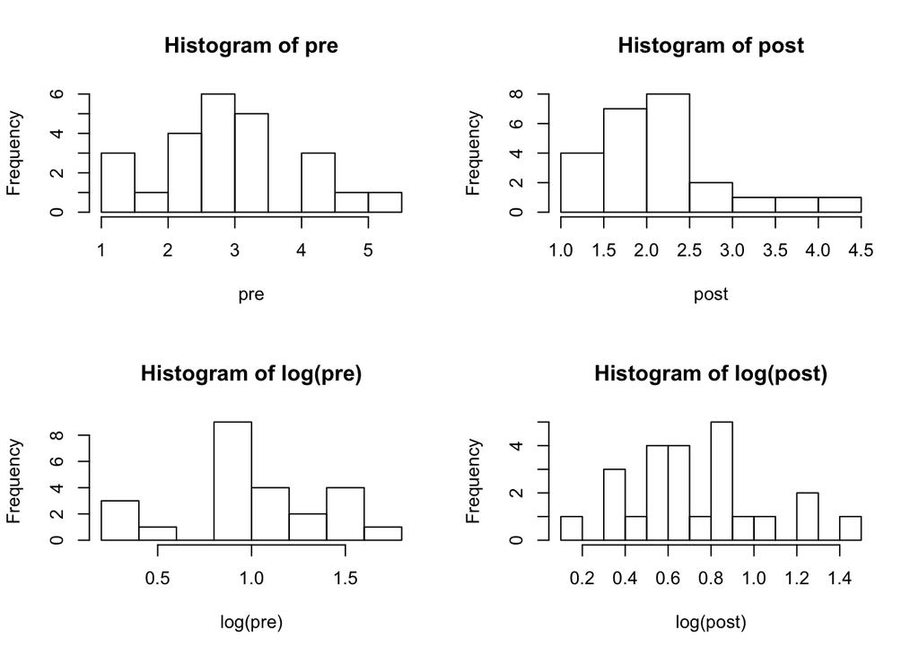

```r
# check distributions of original data with histograms (breaks = 10)
par(mfrow=c(2,2))
hist(pre,breaks=10)
hist(post,breaks=10)

# check distributions after log-transformation
hist(log(pre),breaks=10)
hist(log(post),breaks=10)
```

```r
# Shapiro-Wilk tests
shapiro.test(pre)
```

```
##
##  Shapiro-Wilk normality test
##
## data:  pre
## W = 0.95695, p-value = 0.3802
```

```r
shapiro.test(post)
```

```
##
##  Shapiro-Wilk normality test
##
## data:  post
## W = 0.89421, p-value = 0.01626
```

What do you conclude from your inspection of the normality of the data?

```r
## do t-tests using the original and transformed data
t.test(post,pre,paired=T)
```

```
##
##  Paired t-test
##
## data:  post and pre
## t = -2.8642, df = 23, p-value = 0.008771
## alternative hypothesis: true difference in means is not equal to 0
## 95 percent confidence interval:
##  -1.2321311 -0.1987022
## sample estimates:
## mean of the differences
##              -0.7154167
```

```r
t.test(log(post),log(pre),paired=T)
```

```
##
##  Paired t-test
##
## data:  log(post) and log(pre)
## t = -2.8498, df = 23, p-value = 0.009067
## alternative hypothesis: true difference in means is not equal to 0
## 95 percent confidence interval:
##  -0.46464693 -0.07379456
## sample estimates:
## mean of the differences
##              -0.2692207
```

What are the most striking differences in the results of the $t$-tests? Which $t$-test is more appropriate, and why?

Compute the 95% CI for the post-treatment and pre-treatment samples. Do one of these by hand first, and then use the CI values from one-sample $t$-tests to get both of these automatically (don’t forget to back-transform!)

```r
## compute the 95% CI for the two samples in their original units

#####################################################################
# post-treatment -- by hand!
mean_prime = mean(log(post))
sd_prime = sqrt( sum( (log(post) - mean_prime)^2 /(length(post)-1)) )
se_prime = sd_prime/sqrt(length(post))
tcrit = qt(0.975,df=length(post))
tcrit
```

```
## [1] 2.063899
```

```r
ci_post = c(mean_prime - tcrit*se_prime, mean_prime + tcrit*se_prime)
ci_post
```

```
## [1] 0.5940810 0.8596873
```

```r
ci_post_orig = exp(ci_post)
ci_post_orig
```

```
## [1] 1.811366 2.362422
```

```r
# post-treatment from t-test
t_post = t.test(log(post),mu=mean(log(pre)))
t_post
```

```
##
##  One Sample t-test
##
## data:  log(post)
## t = -4.184, df = 23, p-value = 0.000356
## alternative hypothesis: true mean is not equal to 0.9961049
## 95 percent confidence interval:
##  0.5937748 0.8599936
## sample estimates:
## mean of x
## 0.7268842
```

```r
ci95_post_log = t_post$conf.int[1:2]
ci95_post = exp(ci95_post_log)
ci95_post
```

```
## [1] 1.810811 2.363145
```

```r
#####################################################################
# pre-treatment from t-test
t_pre = t.test(log(pre),mu=mean(log(pre)))
t_pre
```

```
##
##  One Sample t-test
##
## data:  log(pre)
## t = 0, df = 23, p-value = 1
## alternative hypothesis: true mean is not equal to 0.9961049
## 95 percent confidence interval:
##  0.8362093 1.1560005
## sample estimates:
## mean of x
## 0.9961049
```

```r
ci95_pre_log = t_pre$conf.int[1:2]
ci95_pre_log
```

```
## [1] 0.8362093 1.1560005
```

```r
ci95_pre = exp(ci95_pre_log)
ci95_pre
```

```
## [1] 2.307603 3.177201
```

Did you get the same CI for the post-treatment sample when computing by hand and using the `t.test()`? What can you conclude from the 95% CI’s of the two samples?

## Non-parametric (rank-based) tests

When the sample data do not follow a normal distribution, we can use tests that look at the data in terms of their ranks (or ranked differences) instead of their magnitudes.

### Tests for paired data: Sign and Wilcoxon signed-rank tests

For paired data, our null hypothesis is that the paired differences between the groups should end up with about the same number being positive or negative. This works well when the two differences have a similar skew and variance.

#### Sign test

Instead of comparing **means** or mean differences, the **sign test** compares the **median** of a sample to a hypothesized value. For paired data, under the null hypothesis we would expect the medians of two samples to be the same. The hypotheses to be tested are:

$H_o$: The median difference between the groups is zero.

$H_A$: The median difference between the groups is NOT zero.

The sign test simply takes the signs of the paired differences and counts up the number of negative and positive deviations from zero. The $p$-value is then equivalent to the binomial probability for the observed number of negative deviations when the expected probability is 0.5.

The steps are:

- Calculate the pairwise differences between the samples.
- Count the number of nonzero differences $n$.
- The test statistic, let’s call it $k$, is the smaller number of the positive and negative differences.
- Calculate the binomial probability of observing $k$ out of $n$ differences given an expected probability of $\pi = 0.5$.

Compute the binomial probability for the “pre” and “post” triglyceride samples. You can use the `ifelse()` function to find the lower number between the negative and positive differences.

```r
# sign test for the triglyceride data

# difference in the two samples
tri_diff = post - pre

neg_count = sum(tri_diff < 0)
neg_count
```

```
## [1] 18
```

```r
pos_count = sum(tri_diff > 0)
test_stat = ifelse(neg_count < pos_count, neg_count, pos_count)

# binomial probability of seeing neg_count or more
prob_obs = pbinom(test_stat, length(tri_diff), prob=0.5)

# total two-tailed probability
2*prob_obs
```

```
## [1] 0.02265584
```

#### Wilcoxon signed-rank test

The **Wilcoxon signed-rank test** is similar to the sign test except that it takes the sum of all the signed ranks (see below), and it can easily be performed directly in R.

One caveat of this test is that it assumes a symmetric distribution, which limits its applicability. The test is often used when this assumption is violated, so keep this in mind and try not to make the same mistake.

Here we will run the test on the log-transformed data, which is more symmetrical than the original data.

##### Procedure

The steps are:

- Calculate the $N$ differences between the pairs.
- Rank the *absolute* values of the $n$ non-zero differences. Assign the average if there is a tie.
- Also record the sign of the differences, $sgn(x_{2i} - x_{1i})$ for $i \in \{1..N\}$.
- Compute the test statistic $W$, defined as:

$$W = \sum_{i=1}^Nsgn[sgn(x_{2i} - x_{1i}) * R_i]$$

```r
# compute paired log differences
log_tri_diff = log(post) - log(pre)
rank_diff = rank(abs(log_tri_diff))

# Calculate the Wilcoxon W statistic
w_stat = sum(sign(log_tri_diff) * rank_diff)
w_stat
```

```
## [1] -164
```

##### Normal approximation

$W$ has a specific expected distribution under the null. The population mean and variance are:

$$\mu_{W} = 0 ;\ \sigma_{W}^2 = \frac{n(n+1)(2n+1)}{6}$$

When the number of items sampled is more than ~20, we can use a normal approximation to compute a $z$-score, $z = W / \sigma_W$, from which we can obtain a $p$-value.

Below we use the normal approximation to compute a $p$-value for the log-transformed data.

```r
# w stat
n = length(log_tri_diff)
sigma_w = n*(n+1)*(2*n+1) / 6
z_w = w_stat / sqrt(sigma_w)
2*pnorm(z_w)
```

```
## [1] 0.01913671
```

##### Wilcoxon signed-rank test in R

Use the `wilcox.test()` function to test the original and the log-transformed triglyceride data. Don’t forget that we are doing paired tests here.

**Note**: The R implementation of this test uses something called a $V$-statistic, which is a little different than the $W$-statistic: it is the **sum of the ranks** assigned to the differences with a **positive** sign. The test gives the same result when samples are entered in either order.

The normal approximation for the $V$-statistic has parameters:
$$\mu = n(n+1)/4\ ;\ \sigma = n(n+1)(2n+1)/24$$

The $p$-values from both the $W$ and the $V$ are the same.

```r
# computing the V statistic
diff_neg = rank_diff[log_tri_diff < 0]
diff_neg
```

```
##  [1] 10 15 16 19  9 22 23 20  7  6 11  3  5 18  8 12  4 24
```

```r
t_neg = sum(diff_neg)
t_neg
```

```
## [1] 232
```

```r
diff_pos = rank_diff[log_tri_diff > 0]
diff_pos
```

```
## [1]  1 13  2 14 17 21
```

```r
t_pos = sum(diff_pos)
t_pos
```

```
## [1] 68
```

```r
v_stat = min(t_neg,t_pos)
v_stat
```

```
## [1] 68
```

```r
# v stat
mean_v = n*(n+1)/4
sigma_v = n*(n+1)*(2*n+1) / 24
z_v = (v_stat - mean_v) / sqrt(sigma_v)
2*pnorm(z_v)
```

```
## [1] 0.01913671
```

Run the test in R, using both the raw and the log-transformed data.

```r
# test raw data
wilcox.test(post, pre, paired=T)
```

```
##
##  Wilcoxon signed rank test
##
## data:  post and pre
## V = 62, p-value = 0.01051
## alternative hypothesis: true location shift is not equal to 0
```

```r
# test log data
wilcox.test(log(post), log(pre), paired=T)
```

```
##
##  Wilcoxon signed rank test
##
## data:  log(post) and log(pre)
## V = 68, p-value = 0.01787
## alternative hypothesis: true location shift is not equal to 0
```

How do the manual calculations compare to the results of the R tests? Why might these differ?

What do you notice about the differences in the results for the non-transformed vs. the transformed data? Which version is more appropriate?

### Unpaired data: Mann-Whitney-Wilcoxon rank-sum test

If our data are **not normal** and also **not paired**, we can use a **Mann-Whitney U-test** or the equivalent **Wilcoxon rank-sum** test. Some people therefore like to refer to this test as a **Mann-Whitney-Wilcoxon** test. The test is implemented in R as `wilcox.test()`, with the (default) unpaired option.

This test is simlar to the paired signed-rank test, but instead of measuring paired differences and counting positive and negative differences, we compute the sum of ranks for each group in the combined data. This makes intuitive sense because if the data are drawn from a homogeneous population, we would expect the values of the measurements from two random samples to be relatively well interleaved (as if we had shuffled a deck of cards). So, we would expect that the overall sum of ranks should be about the same.

#### Procedure

The hypotheses to be tested are:

$H_o$: The sample distributions are the same.

$H_A$: The sample distributions are NOT the same.

**Note**: The sum of ranks for a sequential set of numbers starting with 1 is $N(N+1)/2$. Check this out for yourself on some small sets of numbers (e.g. 1,2,3…). Intuitively, then, if all the measurements from Sample 1 are much smaller than those from Sample 2, then the minimum sum of ranks for Sample 1 would be $R_1 = n_1(n_1+1)/2$.

#### Computing the U-statistic

The $U$_statistic measures the difference between the observed and minimum ranks. Note that the sum of the $U$-values equals the product of the length of the two samples: $U_1 + U_2 = n_1n_2$.

We can use a simplified method to compute the $U$-statistics:

The population mean and variance (again, ignoring the term for ties for now) are:

$$\mu_U = \frac{n_1n_2}{2}\ ; \ \sigma_{U}^2 = \frac{n_{1}n_{2}}{12} (n_1 + n_2 + 1)$$

Below we will perform the Mann-Whitney-Wilcoxon test on the triglyceride data, pretending that they are not actually paired. First, we compute the statistics by hand:

```r
n = length(pre)  # n is the same for both sets
r_min = n*(n+1)/2 # minimum rank

Data = c(log(pre),log(post))
DataRank = rank(abs(Data))
DataRank
```

```
##  [1] 28.0 40.0 24.0 43.0 38.0 29.0 44.0 37.0 48.0 31.0 36.0  2.0 21.0 19.0  5.0
## [16] 32.5 30.0 45.0  7.0 39.0 35.0 27.0 47.0  8.0  9.0 42.0  6.0 22.5 12.0 10.0
## [31] 14.0  3.0 34.0 13.0 25.0 16.5 26.0  4.0  1.0 46.0 18.0 22.5 32.5 20.0 11.0
## [46] 16.5 15.0 41.0
```

```r
DataRankSums = tapply(DataRank,rep(c("pre","post"),each=n),sum)
DataRankSums
```

```
##  post   pre
## 460.5 715.5
```

```r
t_pre  = DataRankSums["pre"]
t_post  = DataRankSums["post"]

w_pre = t_pre - r_min
w_pre
```

```
##   pre
## 415.5
```

```r
w_post = t_post - r_min
w_post
```

```
##  post
## 160.5
```

```r
mu_w = n^2 / 2
mu_w
```

```
## [1] 288
```

```r
sigma_w = (n^2/12) * (2*n + 1)
sd_w = sqrt(sigma_w)
```

#### Normal approximation

Again, when the number of samples is ~20 or more, we can use the normal approximation. We have $n_1 = n_2 = 24$, so let’s just calculate a $z$-score get our $p$-value.

```r
z_w = (w_post - mu_w)/sd_w
z_w
```

```
##      post
## -2.629006
```

```r
# these are equivalent
2*pnorm(z_w)
```

```
##        post
## 0.008563493
```

```r
2*pnorm(w_post, mean=mu_w, sd=sd_w)
```

```
##        post
## 0.008563493
```

Check the above calculations using the `wilcox.test()` function. Try running the test on both the raw and the log-transformed data.

```r
# raw data
wilcox.test(post,pre, paired=FALSE)
# log-transformed data
wilcox.test(log(post),log(pre), paired=FALSE)
```

[output not shown]

How do the manual results compare with the results from the R functions? Why are they not identical?

How do the results from the raw and transformed data compare?

## Conclusions

Finally, please reflect on the results from the different tests we have performed here. Summarize in a short paragraph below what you have learned from the analysis of the triglyceride dataset.